# Bayesian modeling and prediction for movies by Kunyu HE

As an assumed data scientist at *Paramount Pictures*, I need to work on the data set `movies` to learn what attributes make a movie popular.

**Setup**

**Load packages**

```r
library(ggplot2)
library(dplyr)
library(statsr)
library(BAS)
library(MASS)
library(GGally)
```

**Load data**

```r
load("movies.Rdata")
```

# 1 Part 1: Data

```r
str(movies)
```

```
## Classes 'tbl_df', 'tbl' and 'data.frame':    651 obs. of  32 variables:
##  $ title           : chr  "Filly Brown" "The Dish" "Waiting for Guffman" "The Age of Innocence" ...
##  $ title_type      : Factor w/ 3 levels "Documentary",..: 2 2 2 2 2 1 2 2 1 2 ...
##  $ genre           : Factor w/ 11 levels "Action & Adventure",..: 6 6 4 6 7 5 6 6 5 6 ...
##  $ runtime         : num  80 101 84 139 90 78 142 93 88 119 ...
##  $ mpaa_rating     : Factor w/ 6 levels "G","NC-17","PG",..: 5 4 5 3 5 6 4 5 6 6 ...
##  $ studio          : Factor w/ 211 levels "20th Century Fox",..: 91 202 167 34 13 163 147 118 88 84 ...
##  $ thtr_rel_year   : num  2013 2001 1996 1993 2004 ...
##  $ thtr_rel_month  : num  4 3 8 10 9 1 1 11 9 3 ...
##  $ thtr_rel_day    : num  19 14 21 1 10 15 1 8 7 2 ...
##  $ dvd_rel_year    : num  2013 2001 2001 2001 2005 ...
##  $ dvd_rel_month   : num  7 8 8 11 4 4 2 3 1 8 ...
##  $ dvd_rel_day     : num  30 28 21 6 19 20 18 2 21 14 ...
##  $ imdb_rating     : num  5.5 7.3 7.6 7.2 5.1 7.8 7.2 5.5 7.5 6.6 ...
##  $ imdb_num_votes  : int  899 12285 22381 35096 2386 333 5016 2272 880 12496 ...
```

[output cut: 18 more lines]

The data set `movies` is comprised of 651 observations of 32 variables. The observations are randomly sampled movies produced and released before 2016 from *Rotten Tomatoes* and *IMDB* [1].

*([1]Source: Project Files and Rubric, https://www.coursera.org/learn/linear-regression-model/peer/gIqqL/data-analysis-project, accessed at 09/27/2017)*

**As the observations were collected with random sampling, we can generalize our inference to a population of all the movies on *Rotten Tomatoes* and *IMDB*, which were produced and released before 2016.** However, these websites collect ratings from voluntary behaviours of viewers, therefore the ratings could be biased initially.

**As the collection is observational, we can only conclude on associations among variables.**

# 2 Part 2: Data Manipulation

Calculate following variables for future use before EDA process:

`feature_film`: indicates whether or it is a feature film; `drama`: indicates whether the film genre is a drama; `mpaa_rating_R`: indiactes whether the film was rated “R” or not; `oscar_season`: movie was realeased in October, November, or December. `summer_season`: movie was released in May, June, July, or August.

```r
movies$feature_film <- ifelse(movies$title_type == 'Feature Film', 'yes', 'no')
movies$drama <- ifelse(movies$genre == 'Drama', 'yes', 'no')
movies$mpaa_rating_R <- ifelse(movies$mpaa_rating == 'R', 'yes', 'no')
movies$oscar_season <- sapply( movies$thtr_rel_month, function(value) if ( value >= 10 ) "yes" else "no" )
movies$summer_season <- sapply( movies$thtr_rel_month, function(value) if ( value >= 5 & value <= 8 ) "yes" else "no" )
```

# 3 Part 3: Exploratory Data Analysis

Before EDA, narrow down the data set to a sub-set with the variables of interest and omit the `"NA"` value.

```r
movies_BA <- na.omit(movies[c("audience_score", "feature_film", "drama", "mpaa_rating_R", "runtime", "thtr_rel_year", "oscar_season", "summer_season", "best_pic_nom", "best_pic_win", "best_actor_win", "best_dir_win", "best_actress_win", "imdb_rating", "imdb_num_votes", "critics_score", "top200_box")])
```

## 3.1 Response Variable: `audience_score`

In order to develop a Bayesian regression model to predict `audience_score`, which implies audience ratings on *Rotten Tomatoes*, first we need to scrutinize the dependent variable. Print a summary table and a frequency distribution histogram for it.

```r
summary(movies_BA$audience_score)
```

```
##    Min. 1st Qu.  Median    Mean 3rd Qu.    Max.
##   11.00   46.00   65.00   62.35   80.00   97.00
```

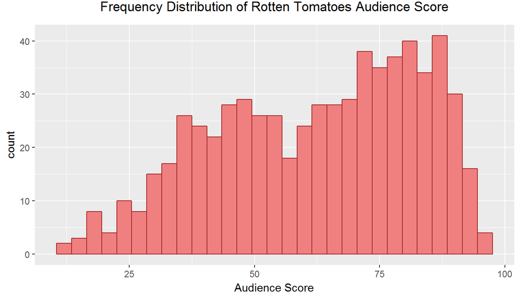

```r
ggplot(data=movies_BA, aes(x=audience_score))+geom_histogram(binwidth = 3, fill="lightcoral", color="Brown")+xlab("Audience Score") + ggtitle("Frequency Distribution of Rotten Tomatoes Audience Score") + theme(plot.title = element_text(hjust=0.5, vjust=3))
```

THe sample distribution is bimodal and left-skewed, with a median larger than the sample mean by approximately 3 points. However, as sample size is much larger than 30, we can assume its distribution to be nearly normal.

## 3.2 `audience_score` against `feature_film`

Scrutinize the association between `audience_score` and `feature_film`. As the predictor is categorical and response variable is numerical, use a box plot.

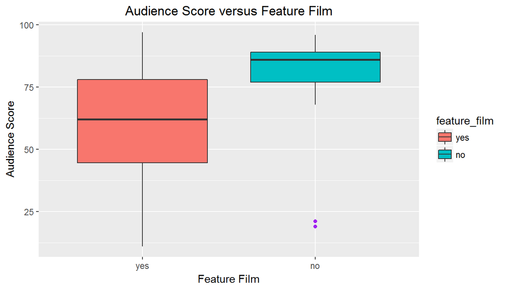

```r
movies_BA$feature_film <- as.factor(movies_BA$feature_film)
movies_BA$feature_film <- relevel(movies_BA$feature_film, ref="yes")
ggplot(movies_BA, aes(x=feature_film, y=audience_score, fill = feature_film)) + geom_boxplot(outlier.color = "purple") + ggtitle("Audience Score versus Feature Film") + labs(x="Feature Film", y="Audience Score") + theme(plot.title = element_text(hjust=0.5, vjust=3))
```

```r
movies_BA %>%
  group_by(feature_film) %>%
  summarise(count=n())
```

```
## # A tibble: 2 x 2
##   feature_film count
##         <fctr> <int>
## 1          yes   591
## 2           no    59
```

**Movies that are not feature films appear to have higher audience scores.** IQR of the non-feature films lies almost entirely above that of feature films on the scale of popularity. Variation in audience score of the non-feature films is much lower, and there are only few ouliers in the group rated extremely low. As the summary tables above shows, there are 59 observations in the non-feature group, which is significantly large to support our impression.

## 3.3 `audience_score` against `imdb_rating`

Collected from another website *IMDB*, `imdb_rating` is a numerical variable and another proxy for the popularity of particular movies. Print a scatter plot and the correlation coefficient to find potential correlation between both variables.

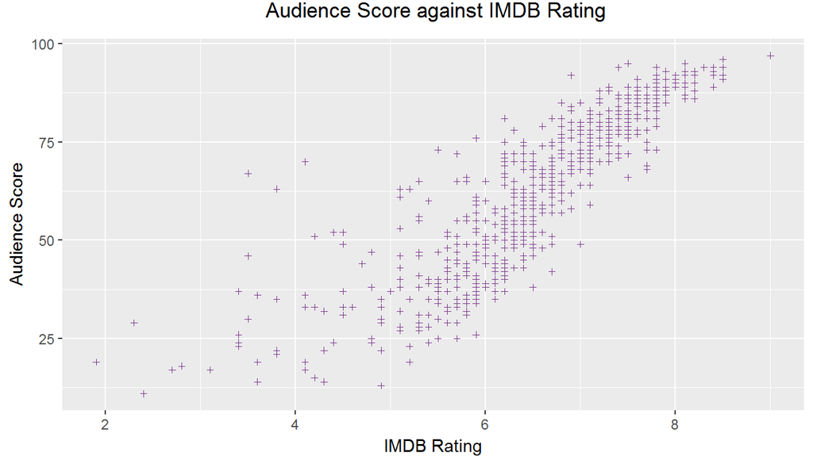

```r
ggplot(movies_BA, aes(y=audience_score, x=imdb_rating))+geom_point(size=1, shape=3, color="mediumorchid4")+ylab("Audience Score")+xlab("IMDB Rating") + ggtitle(" Audience Score against IMDB Rating") + theme(plot.title=element_text(hjust=0.5, vjust=3))
```

```r
cor(movies_BA$audience_score, movies_BA$imdb_rating)
```

```
## [1] 0.8649091
```

**Seems audience voting on *IMDB* and *Rotten Tomatoes* somehow share views about particular films.** From the scatter plot above, we expect a potential positive correlation between `audience_score` and `imdb_rating`. The correlation coefficient is 0.86, which is large enough to support a strong correlation.

# 4 Part 4: Modeling

## 4.1 Model with BIC prior

Construct a Bayesian model with BIC model selection method, where lowest BIC indicates the best fit.

```r
BIC = bas.lm(audience_score ~ ., data = movies_BA, prior = "BIC", modelprior = uniform())
summary(BIC)
```

```
##                     P(B != 0 | Y)    model 1       model 2       model 3
## Intercept              1.00000000     1.0000     1.0000000     1.0000000
## feature_filmno         0.06536947     0.0000     0.0000000     0.0000000
## dramayes               0.04319833     0.0000     0.0000000     0.0000000
## mpaa_rating_Ryes       0.19984016     0.0000     0.0000000     0.0000000
## runtime                0.46971477     1.0000     0.0000000     0.0000000
## thtr_rel_year          0.09068970     0.0000     0.0000000     0.0000000
## oscar_seasonyes        0.07505684     0.0000     0.0000000     0.0000000
## summer_seasonyes       0.08042023     0.0000     0.0000000     0.0000000
## best_pic_nomyes        0.13119140     0.0000     0.0000000     0.0000000
## best_pic_winyes        0.03984766     0.0000     0.0000000     0.0000000
## best_actor_winyes      0.14434896     0.0000     0.0000000     1.0000000
## best_dir_winyes        0.06693898     0.0000     0.0000000     0.0000000
## best_actress_winyes    0.14128087     0.0000     0.0000000     0.0000000
## imdb_rating            1.00000000     1.0000     1.0000000     1.0000000
## imdb_num_votes         0.05773502     0.0000     0.0000000     0.0000000
## critics_score          0.88855056     1.0000     1.0000000     1.0000000
## top200_boxyes          0.04762234     0.0000     0.0000000     0.0000000
## BF                             NA     1.0000     0.9968489     0.2543185
## PostProbs                      NA     0.1297     0.1293000     0.0330000
## R2                             NA     0.7549     0.7525000     0.7539000
## dim                            NA     4.0000     3.0000000     4.0000000
## logmarg                        NA -3615.2791 -3615.2822108 -3616.6482224
##                           model 4       model 5
## Intercept               1.0000000     1.0000000
## feature_filmno          0.0000000     0.0000000
## dramayes                0.0000000     0.0000000
## mpaa_rating_Ryes        1.0000000     1.0000000
## runtime                 0.0000000     1.0000000
## thtr_rel_year           0.0000000     0.0000000
## oscar_seasonyes         0.0000000     0.0000000
## summer_seasonyes        0.0000000     0.0000000
## best_pic_nomyes         0.0000000     0.0000000
## best_pic_winyes         0.0000000     0.0000000
## best_actor_winyes       0.0000000     0.0000000
## best_dir_winyes         0.0000000     0.0000000
## best_actress_winyes     0.0000000     0.0000000
## imdb_rating             1.0000000     1.0000000
## imdb_num_votes          0.0000000     0.0000000
## critics_score           1.0000000     1.0000000
## top200_boxyes           0.0000000     0.0000000
## BF                      0.2521327     0.2391994
## PostProbs               0.0327000     0.0310000
## R2                      0.7539000     0.7563000
## dim                     4.0000000     5.0000000
## logmarg             -3616.6568544 -3616.7095127
```

Plot model diagnostics and model rank image for the model with BIC prior.

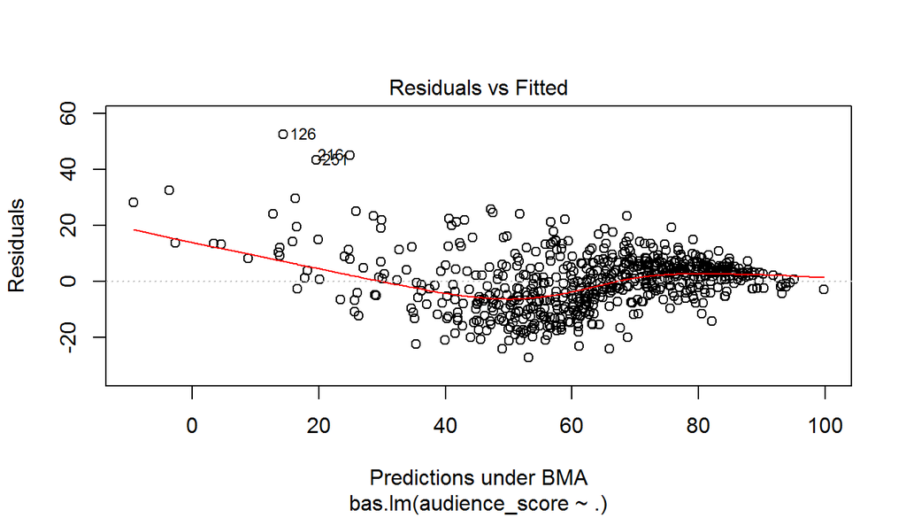

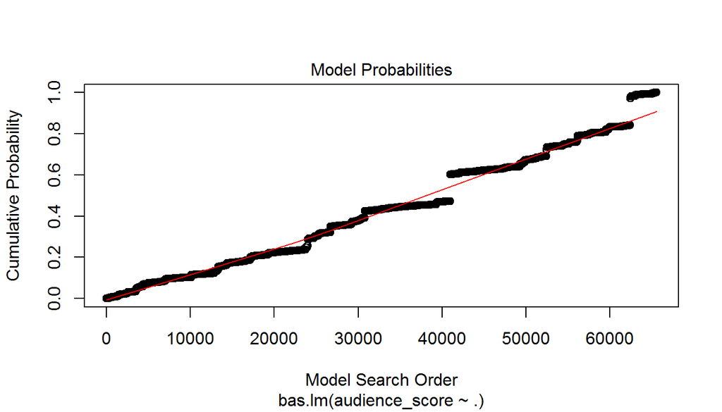

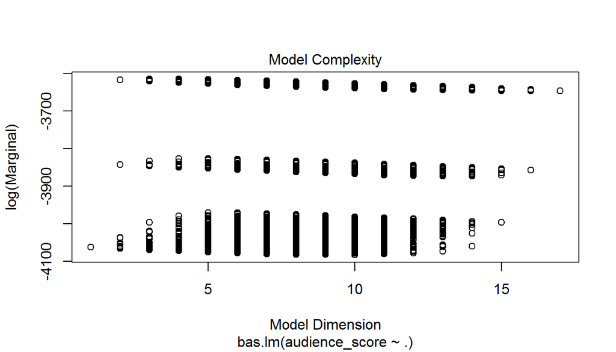

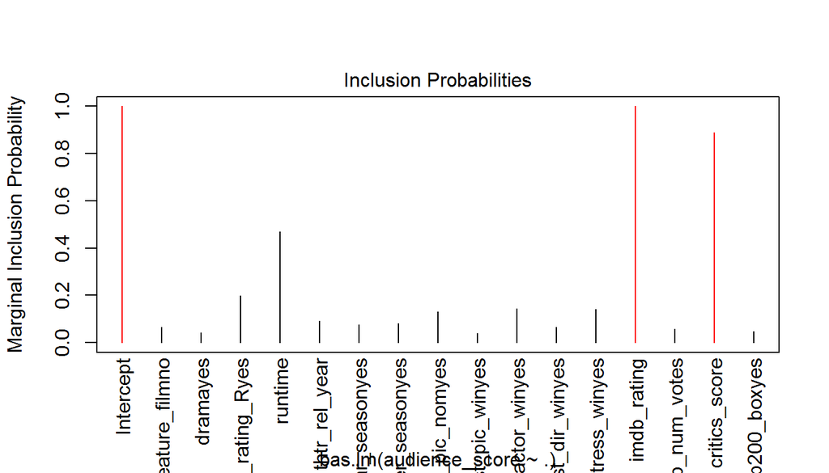

```r
plot(BIC)
```

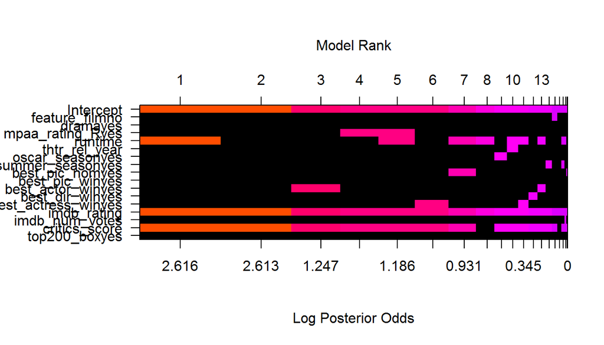

```r
image(BIC, rotate=FALSE, cex.lab= 0.01)
```

In `"Model probabilies"`, probabilities tend to increase along with the search order, which implies a trend of time.

Furthermore, `"Model complexity"` is separated into three distinct sections, possibly resulting from significant effects that some categorical variables in the model take.

**Finally, the `"Inclusion Probabilties"` and model rank suggest a different model, where three variables are listed as potential predictors of `audience_score`: `runtime`, `imdb_rating`, and `critics_score`; with `imdb_rating` and `critics_score` as consistent predictors cross all models.**

## 4.2 Model with Zellner’s g prior

For comparison, construct and select another model with Zellner’s g prior, full.

```r
Zs_full = bas.lm(audience_score ~ ., data = movies_BA, prior = "ZS-full", modelprior = uniform())
summary(Zs_full)
```

```
##                     P(B != 0 | Y)  model 1    model 2    model 3
## Intercept               1.0000000  1.00000  1.0000000  1.0000000
## feature_filmno          0.1632198  0.00000  0.0000000  0.0000000
## dramayes                0.1388781  0.00000  0.0000000  0.0000000
## mpaa_rating_Ryes        0.4237418  0.00000  1.0000000  0.0000000
## runtime                 0.6870515  1.00000  1.0000000  1.0000000
## thtr_rel_year           0.2613814  0.00000  0.0000000  0.0000000
## oscar_seasonyes         0.1791458  0.00000  0.0000000  0.0000000
## summer_seasonyes        0.2021763  0.00000  0.0000000  0.0000000
## best_pic_nomyes         0.3749717  0.00000  0.0000000  1.0000000
## best_pic_winyes         0.1206440  0.00000  0.0000000  0.0000000
## best_actor_winyes       0.2919890  0.00000  0.0000000  0.0000000
## best_dir_winyes         0.1678467  0.00000  0.0000000  0.0000000
## best_actress_winyes     0.3186627  0.00000  0.0000000  0.0000000
## imdb_rating             1.0000000  1.00000  1.0000000  1.0000000
## imdb_num_votes          0.1847324  0.00000  0.0000000  0.0000000
## critics_score           0.9386794  1.00000  1.0000000  1.0000000
## top200_boxyes           0.1345747  0.00000  0.0000000  0.0000000
## BF                             NA  1.00000  0.7995383  0.6237483
## PostProbs                      NA  0.02150  0.0172000  0.0134000
## R2                             NA  0.75490  0.7563000  0.7561000
## dim                            NA  4.00000  5.0000000  5.0000000
## logmarg                        NA 21.31889 21.0951703 20.8468828
##                        model 4    model 5
## Intercept            1.0000000  1.0000000
## feature_filmno       0.0000000  0.0000000
## dramayes             0.0000000  0.0000000
## mpaa_rating_Ryes     1.0000000  0.0000000
## runtime              1.0000000  1.0000000
## thtr_rel_year        0.0000000  1.0000000
## oscar_seasonyes      0.0000000  0.0000000
## summer_seasonyes     0.0000000  0.0000000
## best_pic_nomyes      1.0000000  0.0000000
## best_pic_winyes      0.0000000  0.0000000
## best_actor_winyes    0.0000000  0.0000000
## best_dir_winyes      0.0000000  0.0000000
## best_actress_winyes  0.0000000  0.0000000
## imdb_rating          1.0000000  1.0000000
## imdb_num_votes       0.0000000  0.0000000
## critics_score        1.0000000  1.0000000
## top200_boxyes        0.0000000  0.0000000
## BF                   0.4672512  0.3571704
## PostProbs            0.0100000  0.0077000
## R2                   0.7574000  0.7557000
## dim                  6.0000000  5.0000000
## logmarg             20.5580027 20.2893489
```

Plot model diagnostics and model rank image for the model with Zellner’s g prior, full.

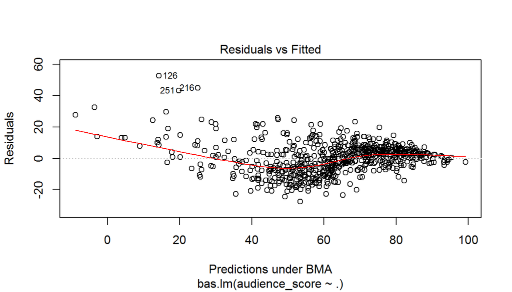

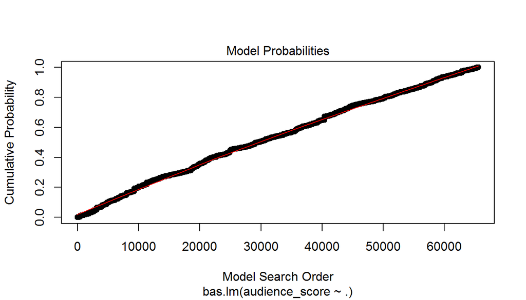

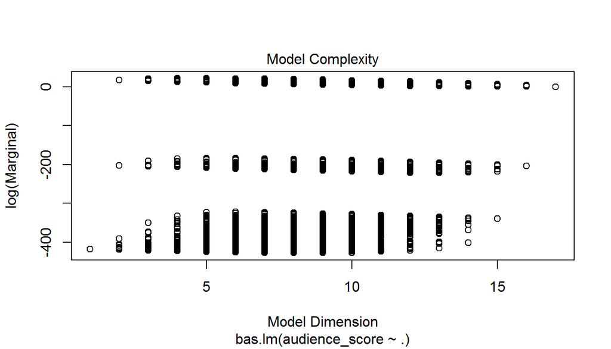

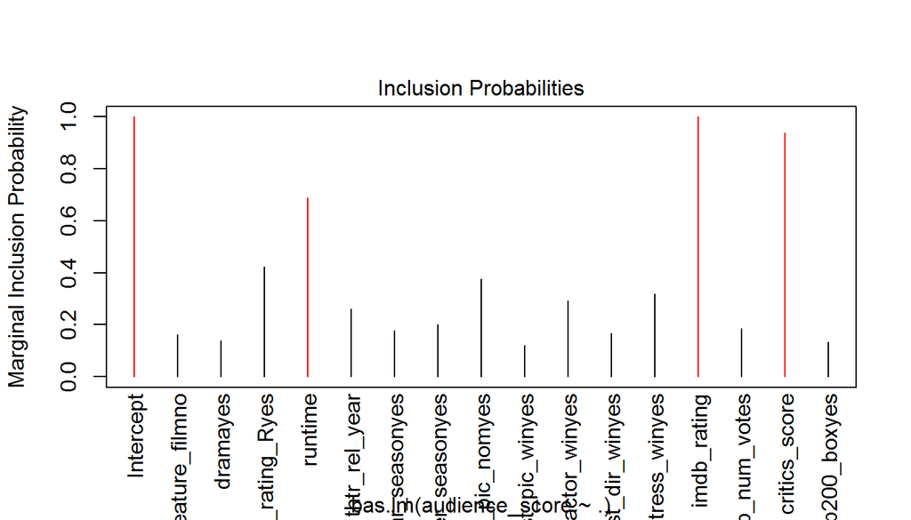

```r
plot(Zs_full)
```

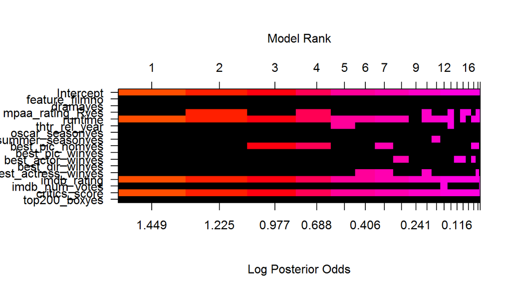

```r
image(Zs_full, rotate=FALSE, cex.lab= 0.01)
```

However, the `"Model Probabilities"` plot shows consistent cumulative model probability for each time a new model is sampled. The plot shows almost straight upward line indicating added probability as more models are added.

Furthermore, `"Model complexity"` is separated into three distinct sections, possibly resulting from significant effects that some categorical variables in the model take.

**Finally, the `"Inclusion Probabilties"` and model rank suggest a different model, where three variables are listed as potential predictors of `audience_score`: `runtime`, `imdb_rating`, and `critics_score`; with `imdb_rating` and `critics_score` as consistent predictors cross all models.**

## 4.3 Final Model

Our final model would include merely three predictors, `runtime`, `imdb_rating`, and `critics_score`. Construct the model and print a summary table for both the model and its coefficients.

```r
final_model = bas.lm(audience_score ~ runtime + imdb_rating + critics_score, data = movies_BA, prior = "BIC", modelprior = uniform())
summary(final_model)
```

```
##               P(B != 0 | Y)    model 1       model 2       model 3
## Intercept         1.0000000     1.0000     1.0000000     1.0000000
## runtime           0.5101554     1.0000     0.0000000     1.0000000
## imdb_rating       1.0000000     1.0000     1.0000000     1.0000000
## critics_score     0.9050549     1.0000     1.0000000     0.0000000
## BF                       NA     1.0000     0.9968489     0.1255707
## PostProbs                NA     0.4532     0.4518000     0.0569000
## R2                       NA     0.7549     0.7525000     0.7509000
## dim                      NA     4.0000     3.0000000     3.0000000
## logmarg                  NA -3615.2791 -3615.2822108 -3617.3539409
##                     model 4       model 5
## Intercept      1.000000e+00  1.000000e+00
## runtime        0.000000e+00  0.000000e+00
## imdb_rating    1.000000e+00  0.000000e+00
## critics_score  0.000000e+00  1.000000e+00
## BF             8.390939e-02  1.012980e-99
## PostProbs      3.800000e-02  0.000000e+00
## R2             7.481000e-01  4.958000e-01
## dim            2.000000e+00  2.000000e+00
## logmarg       -3.617757e+03 -3.843222e+03
```

```r
confint(coefficients(final_model))
```

```
##                      2.5%     97.5%        beta
## Intercept     61.58838637 63.112656 62.34769231
## runtime       -0.08186243  0.000000 -0.02755783
## imdb_rating   13.73147582 16.611441 14.96315740
## critics_score  0.00000000  0.106745  0.06498060
## attr(,"Probability")
## [1] 0.95
## attr(,"class")
## [1] "confint.bas"
```

**The posterior probability of the final model is 0.453, which is significantly high.** The formula is:

$$audience_score = 62.35 - 0.028 \cdot runtime + 14.963 \cdot imdb_rating + 0.065 \cdot critics_score$$

**In conclusion, ceteris paribus, we expect a 0.028 decrease of `audience_score` with a one-minute increase in `runtime`, on average; ceteris paribus, we expect a 14.963 increase of `audience_score` with a one point increase in `imdb_rating`, on average; ceteris paribus, we expect a 0.065 increase of `audience_score` with a one point increase in `critics_score`, on average.**

# 5 Part 5: Prediction

For prediction, pick *American Assasin*[3]. Caculate by coding:

*([3]Source: American Assasin, IMDB at http://www.imdb.com/title/tt1961175/?ref_=inth_ov_tt, Rotten Tomatoes at https://www.rottentomatoes.com/m/american_assassin_2017, both accessed on 27/09/2017)*

```r
AA <-data.frame(119, 6.6, 33)
names(AA)<-c("runtime", "imdb_rating", "critics_score")
predict_AA_1 <- predict(final_model,AA,estimator="BPM", se.fit=TRUE)
predict_AA_2 <- predict(final_model,AA,estimator="MPM", se.fit=TRUE)
predict_AA_1$fit
```

```
## [1] 62.13259
## attr(,"model")
## [1] 0 2 3
## attr(,"best")
## [1] 4
```

```r
predict_AA_2$fit
```

```
## [1] 61.5314
## attr(,"model")
## [1] 0 1 2 3
## attr(,"best")
## [1] 1
```

**According to the prediction, the audience score of *American Assasin* should be 61-62, where the true score is 69. Our prediction is relatively close.**

# 6 Part 6: Conclusion

**We conclude that based on the given data set `movies`, `critics_score`, `imdb_rating` are predictors positively correlate with `audience_score`; `runtime`, contrarily, negatively correlates with `audience_score`; and `imdb_rating` take the strongest effect on audience score of a movies on *Rotten Tomatoes* and *IMDB*, which were produced and released before 2016.**

One shortcoming of this analysis is the lack of prior model. It will greatly enhance our analysis if we research more and use a better prior model for our regression.